# GCA Analysis Notebook

Bud Talbot, Derek Briggs

## Load data

Load data from GCA_ALL_DATA_fa15_sp16_fa16_03302017, name the new data frame FSF_alldata (FSF = “Fall Spring Fall”)

```r
library(readr)
FSF_alldata <- read_csv("C:/Users/talbotr/Desktop/Keck/FSF_alldata.csv")
```

## Subset data

This code subsets GCA pre and post responses from FSF all data- including cl, Sex and ethnicity codes

```r
GCA_prepost <- subset(FSF_alldata, select=c(StudentID, Semester, cl, Pre1:Post25, Sex:Demo4White5))
```

Use lapply to find means of all GCA pre and post item responses and write to new list. This code is not implemented yet

```r
GCA_item_Means <- lapply(3:52, mean)
```

## Calculate GCA Pre and Post total scores

```r
Pre_tot <- rowSums(GCA_prepost[4:28], na.rm = TRUE)
Post_tot <- rowSums(GCA_prepost[29:53], na.rm = TRUE)
GCA_prepost$Pre_tot <- Pre_tot
GCA_prepost$Post_tot <- Post_tot
```

## Calculate and Effect Size

```r
raw_gain <- (GCA_prepost[62] - GCA_prepost[61])
norm_gain <- raw_gain/(25 - GCA_prepost[61])
GCA_prepost$gain <- raw_gain
GCA_prepost$norm_gain <- norm_gain
```

## Filter and calculate class and ES

Now filter (using dplyr) FSF_alldata for cl = 1 and Semester = Fa2015 from GCA_prepost, then calculate ES and g for this class (class 1 from Fall 2015)

```r
library(dplyr)
cl1f15 <- filter(GCA_prepost, Semester=="Fa2015", cl==1)
cl1f15_ES <- (mean(cl1f15$Post_tot, na.rm = TRUE) - mean(cl1f15$Pre_tot, na.rm = TRUE))/sd(cl1f15$Pre_tot, na.rm = TRUE)
cl1f15_g <- (mean(cl1f15$Post_tot, na.rm = TRUE) - mean(cl1f15$Pre_tot, na.rm = TRUE))/(25-mean(cl1f15$Pre_tot, na.rm = TRUE))
cl1f15gains <- c(cl1f15_ES, cl1f15_g)
print(cl1f15gains)
```

```
## [1] 1.1726047 0.3095731
```

I need to make the above code a function and then use lapply to iterate over all classes and Semesters, or just increment and loop it over and over. Then write each resulting vector (e.g. cl1f15gains) to a new table. Thoughts on how to code that nicely?

## Plot histogram of pre and post GCA for a class

Plot a histogram of class 1 Fall 2015 pre and post GCA scores

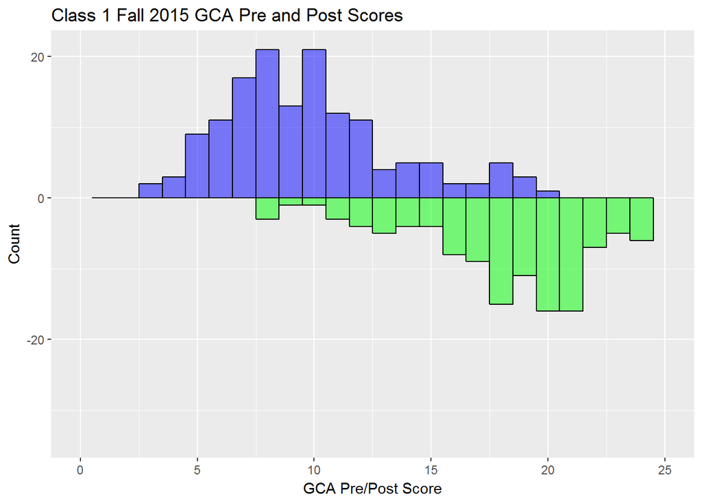

```r
library(ggplot2)
library(RColorBrewer)
df <-  data.frame(x = cl1f15$Pre_tot, x2 = cl1f15$Post_tot)

g <-  ggplot(df, aes(x)) + geom_histogram(aes(x = x, y = ..count..),
                  binwidth = 1, color="black", fill="blue", alpha=0.5) +
  geom_histogram( aes(x = x2, y = -..count..),
                  binwidth = 1, color="black", fill= "green", alpha=0.5) +
  scale_x_continuous(name = "GCA Pre/Post Score",
                     limits=c(0, 25)) +
  scale_y_continuous(name = "Count") +
  ggtitle("Class 1 Fall 2015 GCA Pre and Post Scores")
print(g)
```

Or this if we don’t want the post distribution inverted

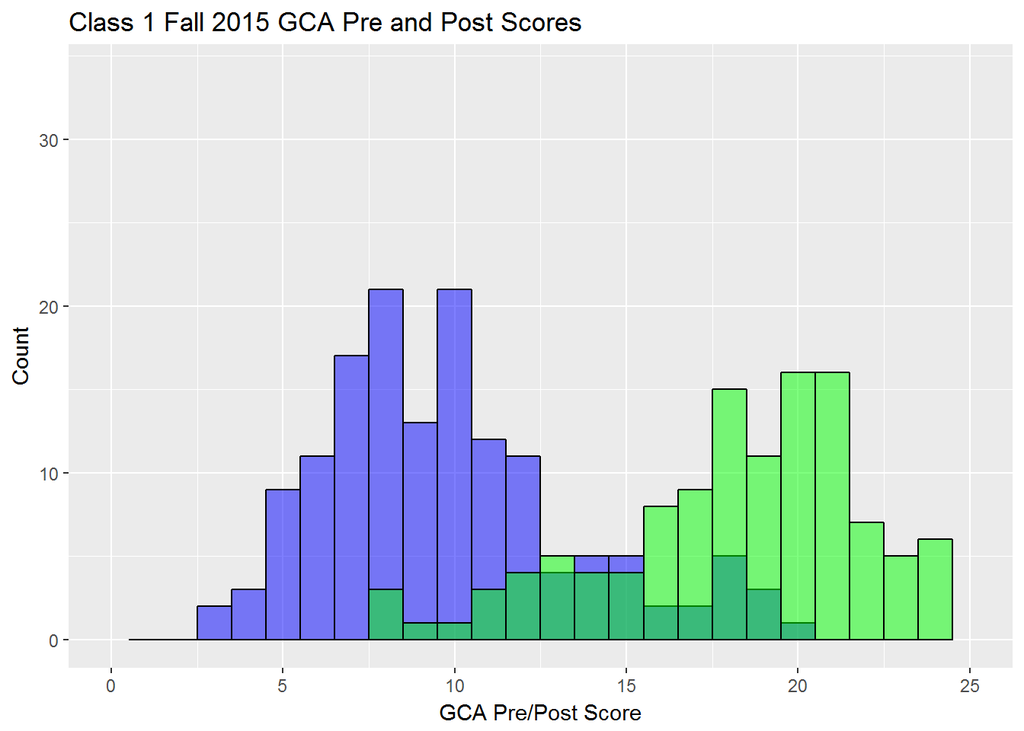

```r
g2 <-  ggplot(df, aes(x)) + geom_histogram(aes(x = x, y = ..count..),
                  binwidth = 1, color="black", fill="blue", alpha=0.5) +
  geom_histogram( aes(x = x2, y = ..count..),
                  binwidth = 1, color="black", fill= "green", alpha=0.5) +
  scale_x_continuous(name = "GCA Pre/Post Score",
                     limits=c(0, 25)) +
  scale_y_continuous(name = "Count") +
  ggtitle("Class 1 Fall 2015 GCA Pre and Post Scores")
print(g2)
```

## Local item and ES

Next we need to calculate pre and post totals and gains (, ES) for the local items for each class

## GCA and local gain scores by learning goals

Then we need to code new vars for GCA and local scores by learning goal, and find gains for these item groupings